# Test for association between Na+ consumption and life expectancy, from 1990 to 2010

**Last edited: December 22, 2015**

**Kellie Ottoboni**

```r
set.seed(38)
library(dplyr)
library(Hmisc)
```

## Data cleaning

We need to clean up the data. This includes removing unwanted variables (we keep per capita GDP, alcohol consumption, and per capita cigarette consumption only) and imputing the missing values of the predictors. In particular:

- We merge two data sources. One contains the economic variables, life expectancy, alcohol, and sodium consumption. The other contains the annual number of cigarettes smoked per capita.
- We impute the missing 2010 sex-specific alcohol consumption for Taiwan using a linear regression of male and female life expectancy, male and female salt consumption, per capita GDP, and per capita annual cigarette consumption on sex-specific alcohol consumption. Then we impute population average alcohol consumption by taking a weighted average of male and female alcohol consumption, using the proportion of the population that is male/female as the weights.
- We impute the missing 1990 overall alcohol consumption for Taiwan in the same way as before, regressing predictors on overall alcohol consumption. Then we use the proportion of alcohol consumption in 2010 attributable to males and females to estimate the male and female sex-specific alcohol consumption in 1990, respectively.

```r
salt <- read.table("../Data/omnibus_data.csv", sep = "\t", header = TRUE)
smoke <- read.table("../Data/smoking_t14.csv", sep = ",", header = TRUE)
smoke <- dplyr::select(smoke, country_name_p, annual_pc_smoking_1990, annual_pc_smoking_2010)


salt <- mutate(salt, popF_prop = popF/(popF + popM), popM_prop = popM/(popF + popM))
salt$popF_prop[is.na(salt$popF)] <- 0.5; salt$popM_prop[is.na(salt$popM)] <- 0.5
salt$etohboth <- ifelse(is.na(salt$etohboth), salt$popM_prop*salt$etohM + salt$popF_prop*salt$etohF, salt$etohboth)

salt <- arrange(salt, country, year)
salt_filt <- dplyr::select(salt, country, country_name_p, e0_M, e0_F, year, Na_M, Na_F, etohboth, etohM, etohF, pc_gdp, popM_prop, popF_prop)

salt2010 <- filter(salt_filt, year == 2010)
salt2010 <- merge(smoke, salt2010)
salt2010 <- dplyr::select(salt2010, -annual_pc_smoking_1990, -country_name_p) %>% mutate(smoking = annual_pc_smoking_2010) %>% dplyr::select(-annual_pc_smoking_2010)
etohM_mod <- lm(etohM~ e0_M + e0_F + Na_M + Na_F + pc_gdp + smoking, data = salt2010)
etohF_mod <- lm(etohF~ e0_M + e0_F + Na_M + Na_F + pc_gdp + smoking, data = salt2010)
twn <- which(is.na(salt2010$etohM))
salt2010[twn, "etohM"] <- predict(etohM_mod, salt2010[twn,]); salt2010[twn, "etohF"] <- predict(etohF_mod, salt2010[twn,])
salt2010[twn, "etohboth"] <- (salt2010$popM_prop*salt2010$etohM + salt2010$popF_prop*salt2010$etohF)[twn]

salt1990 <- filter(salt_filt, year == 1990)
salt1990 <- merge(smoke, salt1990)
salt1990 <- dplyr::select(salt1990, -annual_pc_smoking_2010, -country_name_p)  %>% mutate(smoking = annual_pc_smoking_1990) %>% dplyr::select(-annual_pc_smoking_1990)
etohboth_mod <- lm(etohboth ~ e0_M + e0_F + Na_M + Na_F + pc_gdp + smoking, data = salt1990)
twn <- which(is.na(salt1990$etohboth))
salt1990[twn, "etohboth"] <- predict(etohboth_mod, salt1990[twn,])
salt1990$etohM     <- salt1990$etohboth * (salt2010$etohM)/(salt2010$popM_prop*salt2010$etohM+salt2010$popF_prop*salt2010$etohF)
salt1990$etohF     <- salt1990$etohboth * (salt2010$etohF)/(salt2010$popM_prop*salt2010$etohM+salt2010$popF_prop*salt2010$etohF)
```

## Modeling + permutation tests

The goal is to predict change in life expectancy at age 30 without using Na+ consumption as a predictor. We will several different models and pick the one with the best in-sample fit. We start by loading in the model-selection function. Then, we carry out model selection on the male data and female data to generate predictions.

We try fitting several models to the data: linear models, tree methods, etc., and we tune the parameters of each model using bootstrapping (all this is done using the `train` function). Finally, we choose the model with the lowest in-sample prediction error, measured as mean squared error here.

We need to import [the ModelMatch library](https://github.com/kellieotto/ModelMatch) to carry out the statistical inference. Using `ModelMatch` we’ll conduct permutation tests for the correlation between treatment (change in sodium consumption) and the outcome of interest (change in 30-year life expectancy). We do this for both the observed change in life expectancy and for the residuals of the model (predicted - true change in 30-year life expectancy). We’ll refer to these residuals as ``excess mortality’’ – a difference in life expectancy not explained by the control variables.

```r
source("../Code/modeling.R")
library(ModelMatch)
```

# Change over time

The first analysis we do looks at *changes* in these variables from 1990 to 2010. By taking the difference between levels in 2010 and 1990, we control for baseline differences between countries.

```r
countries <- salt2010$country
salt_diff <- salt2010[,-1]-salt1990[,-1]
salt_diff <- cbind(countries, salt_diff)
salt_diff <- filter(salt_diff, !is.na(e0_M))

male <- dplyr::select(salt_diff, e0_M, etohM, smoking, pc_gdp)
male_Na <- salt_diff$Na_M
colnames(male) <- gsub("_M", "", colnames(male))
female <- dplyr::select(salt_diff,  e0_F, etohF, smoking, pc_gdp)
female_Na <- salt_diff$Na_F
colnames(female) <- gsub("_F", "", colnames(female))
```

## Results

### Unadjusted correlation

We begin by looking at the correlation between the change in sodium consumption and change in life expectancy at age 30.

```r
unadjusted_corr_M <- permu_pearson(prediction = male$e0, response = 0, treatment = male_Na, iters = 10000)
unadjusted_corr_F <- permu_pearson(prediction = female$e0, response = 0, treatment = female_Na, iters = 10000)
```

```
##           Estimate Upper p Lower p Two-sided p
## Male   -0.41395997  0.9908  0.0092      0.0150
## Female  0.05121131  0.3884  0.6116      0.7735
```

### Adjusted for alcohol consumption

Next, we predict change in life expectancy using per capita GDP and ETOH consumption. We look at the correlation between excess mortality (predicted - actual change in life expectancy) and change in sodium consumption.

```r
cat('Model selection: male \n')
mod_M_1 <- male %>% select(-smoking) %>% choose_model()
pred_M_1 <- predict(mod_M_1, male)
res_M_1 <- permu_pearson(prediction = pred_M_1, response = male$e0, treatment = male_Na, iters = 10000)
cat('Model selection: female \n')
mod_F_1 <- female %>% select(-smoking) %>% choose_model()
pred_F_1 <- predict(mod_F_1, female)
res_F_1 <- permu_pearson(prediction = pred_F_1, response = female$e0, treatment = female_Na, iters = 10000)
```

```
## Model selection: male
##
##            Linear regression        Polynomial regression
##                     1.274151                     1.274151
##                         CART                  Bagged CART
##                     1.687890                     1.426582
##                Random forest Stochastic gradient boosting
##                     0.310744                     1.158080
## Model selection: female
##
##            Linear regression        Polynomial regression
##                    0.8176461                    0.8176461
##                         CART                  Bagged CART
##                    1.2395969                    0.7666225
##                Random forest Stochastic gradient boosting
##                    0.2064480                    0.4291248
```

```
##           Estimate Upper p Lower p Two-sided p
## Male    0.01491476  0.4758  0.5242      0.9304
## Female -0.33063987  0.9753  0.0247      0.0530
```

### Adjusted for alcohol consumption and smoking

Finally, we predict change in life expectancy using per capita GDP, ETOH consumption, and annual cigarettes per capita. We look at the correlation between excess mortality (predicted - actual change in life expectancy) and change in sodium consumption.

```r
cat('Model selection: male \n')
mod_M <- male %>% choose_model()
pred_M <- predict(mod_M, male)
res_M <- permu_pearson(prediction = pred_M, response = male$e0, treatment = male_Na, iters = 10000)
cat('Model selection: female \n')
mod_F <- female %>% choose_model()
pred_F <- predict(mod_F, female)
res_F <- permu_pearson(prediction = pred_F, response = female$e0, treatment = female_Na, iters = 10000)
```

```
## Model selection: male
##
##            Linear regression        Polynomial regression
##                    1.2252001                    1.2252001
##                         CART                  Bagged CART
##                    1.6878900                    1.4460538
##                Random forest Stochastic gradient boosting
##                    0.3406444                    1.3656781
## Model selection: female
##
##            Linear regression        Polynomial regression
##                    0.8150245                    0.8150245
##                         CART                  Bagged CART
##                    0.8374598                    0.7548522
##                Random forest Stochastic gradient boosting
##                    0.2231958                    0.6367887
```

```
##           Estimate Upper p Lower p Two-sided p
## Male   -0.01222696  0.5313  0.4687      0.9426
## Female -0.33876040  0.9735  0.0265      0.0475
```

## Plots

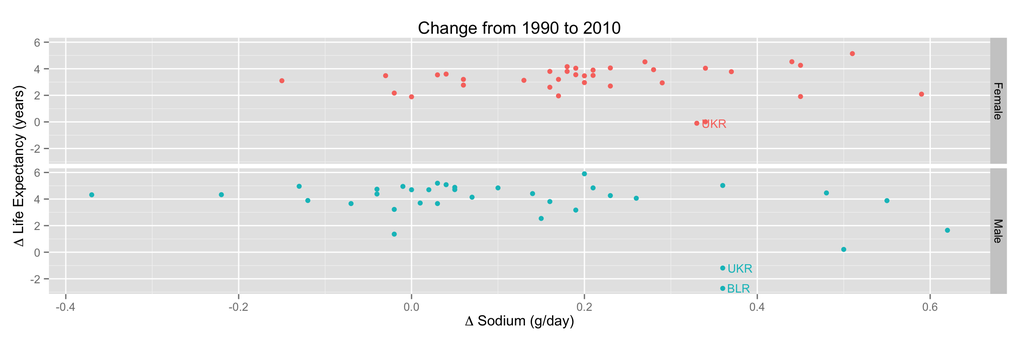

```r
library(ggplot2)

dat <- data.frame("sex"     = c(rep("Male",nrow(male)), rep("Female",nrow(female))),
                  "sodium"  = as.numeric(c(male_Na, female_Na)),
                  "le"      = c(male$e0, female$e0),
                  "country" = rep(salt_diff$countries, 2),
                  "ex_mort" = c(pred_M-male$e0, pred_F-female$e0),
                  stringsAsFactors = FALSE)
p1 <- qplot(sodium, le, data = dat, facets = sex~., colour = sex) + theme(legend.position = "none") + labs(x = expression(paste(Delta, " Sodium (g/day)")), y = expression(paste(Delta, " Life Expectancy (years)")), title = "Change from 1990 to 2010") + geom_text(aes(label=ifelse(le<0,paste(country),"")) , hjust=-0.2, size = 3.5)
p1
```

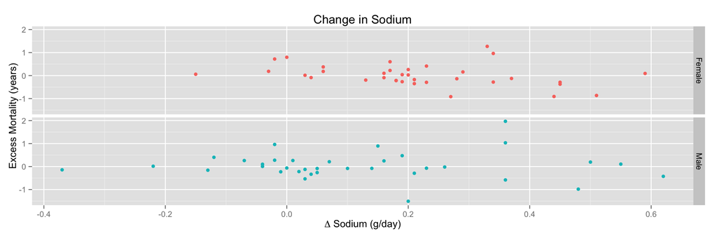

```r
p2 <- qplot(sodium, ex_mort, data = dat, facets = sex~., colour = sex) + theme(legend.position = "none") + labs(x = expression(paste(Delta, " Sodium (g/day)")), y = "Excess Mortality (years)", title = "Change in Sodium") + geom_text(aes(label=ifelse(ex_mort < -2, paste(country), "")), hjust=-0.2, size = 3.5)
p2
```

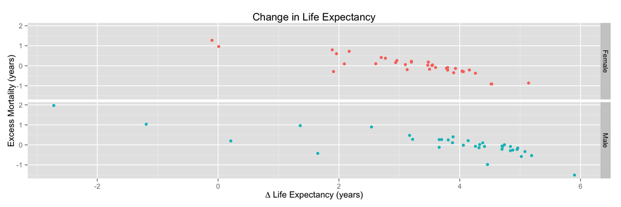

```r
p3 <- qplot(le, ex_mort, data = dat, facets = sex~., colour = sex) + theme(legend.position = "none") + labs(x = expression(paste(Delta, " Life Expectancy (years)")), y = "Excess Mortality (years)", title = "Change in Life Expectancy")  + geom_text(aes(label=ifelse(ex_mort < -2, paste(country), "")), hjust=1.1, size = 3.5)
p3
```

# Absolute associations

The previous analysis accounted for changes in life expectancy and in sodium, alcohol, and tobacco consumption from 1990 to 2010. We also want to look at the correlation between sodium and life expectancy at a fixed point in time, rather than taking differences.

Aside from the data preparation, the analysis will be the same as the previous section.

```r
salt_imputed <- rbind(salt1990, salt2010)
salt_imputed <- salt_imputed %>% filter(!is.na(e0_M) & !is.na(e0_F))
male <- dplyr::select(salt_imputed, e0_M, etohM, smoking, pc_gdp)
male_Na <- salt_imputed$Na_M
colnames(male) <- gsub("_M", "", colnames(male))
female <- dplyr::select(salt_imputed,  e0_F, etohF, smoking, pc_gdp)
female_Na <- salt_imputed$Na_F
colnames(female) <- gsub("_F", "", colnames(female))
```

## Results

### Unadjusted correlation

We look at the correlation between sodium consumption and life expectancy at age 30.

```r
unadjusted_corr_M <- permu_pearson(prediction = male$e0, response = 0, treatment = male_Na, iters = 10000)
unadjusted_corr_F <- permu_pearson(prediction = female$e0, response = 0, treatment = female_Na, iters = 10000)
```

```
##           Estimate Upper p Lower p Two-sided p
## Male   -0.10943270  0.8198  0.1802      0.3609
## Female  0.09618208  0.2147  0.7853      0.4253
```

### Adjusted for alcohol consumption

Next, we predict life expectancy using ETOH consumption and per capita GDP. We look at the correlation between excess mortality (predicted - actual life expectancy) and sodium consumption.

```r
cat('Model selection: male \n')
mod_M_1 <- male %>% select(-smoking) %>% choose_model()
pred_M_1 <- predict(mod_M_1, male)
res_M_1 <- permu_pearson(prediction = pred_M_1, response = male$e0, treatment = male_Na, iters = 10000)
cat('Model selection: female \n')
mod_F_1 <- female %>% select(-smoking) %>% choose_model()
pred_F_1 <- predict(mod_F_1, female)
res_F_1 <- permu_pearson(prediction = pred_F_1, response = female$e0, treatment = female_Na, iters = 10000)
```

```
## Model selection: male
##
##            Linear regression        Polynomial regression
##                     6.120246                     6.120246
##                         CART                  Bagged CART
##                     3.206689                     3.437013
##                Random forest Stochastic gradient boosting
##                     1.285666                     3.215312
## Model selection: female
##
##            Linear regression        Polynomial regression
##                    3.4307459                    3.4307459
##                         CART                  Bagged CART
##                    1.7422838                    1.6508313
##                Random forest Stochastic gradient boosting
##                    0.5895975                    1.4705535
```

```
##          Estimate Upper p Lower p Two-sided p
## Male    0.1456769  0.1146  0.8854      0.2325
## Female -0.1725817  0.9249  0.0751      0.1508
```

### Adjusted for alcohol consumption and smoking

Finally, we predict life expectancy using per capita GDP, ETOH consumption, annual cigarettes per capita. We look at the correlation between excess mortality (predicted - actual life expectancy) and sodium consumption.

```r
cat('Model selection: male \n')
mod_M <- male %>% choose_model()
pred_M <- predict(mod_M, male)
res_M <- permu_pearson(prediction = pred_M, response = male$e0, treatment = male_Na, iters = 10000)
cat('Model selection: female \n')
mod_F <- female %>% choose_model()
pred_F <- predict(mod_F, female)
res_F <- permu_pearson(prediction = pred_F, response = female$e0, treatment = female_Na, iters = 10000)
```

```
## Model selection: male
##
##            Linear regression        Polynomial regression
##                     6.091116                     6.091116
##                         CART                  Bagged CART
##                     4.799671                     2.984485
##                Random forest Stochastic gradient boosting
##                     1.053884                     1.530884
## Model selection: female
##
##            Linear regression        Polynomial regression
##                    3.4302205                    3.4302205
##                         CART                  Bagged CART
##                    1.4599199                    1.4012552
##                Random forest Stochastic gradient boosting
##                    0.5113822                    0.7751458
```

```
##          Estimate Upper p Lower p Two-sided p
## Male    0.1299942  0.1361  0.8639      0.2779
## Female -0.1917331  0.9471  0.0529      0.1067
```

### R and package versions used